# Logistic regression

*Describe the work you have done this week and summarize your learning.*

- Describe your work and results clearly.
- Assume the reader has an introductory course level understanding of writing and reading R code as well as statistical methods.
- Assume the reader has no previous knowledge of your data or the more advanced methods you are using.

```r
date()
```

```
## [1] "Thu Nov 17 18:09:05 2022"
```

### 2. Reading data

We’ll be investigating a combined data set on student alcohol consumption. The data was collected with surveys and school reports and it combines the math and portuguese subjects’ grades together.

```r
#read data
library(tidyverse)
alc <- read_csv("data/alc.csv",show_col_types=FALSE)
#check the involved variables
colnames(alc)
```

```
##  [1] "school"     "sex"        "age"        "address"    "famsize"
##  [6] "Pstatus"    "Medu"       "Fedu"       "Mjob"       "Fjob"
## [11] "reason"     "guardian"   "traveltime" "studytime"  "schoolsup"
## [16] "famsup"     "activities" "nursery"    "higher"     "internet"
## [21] "romantic"   "famrel"     "freetime"   "goout"      "Dalc"
## [26] "Walc"       "health"     "failures"   "paid"       "absences"
## [31] "G1"         "G2"         "G3"         "alc_use"    "high_use"
```

The collected data includes several background factors such as the attended school, sex, age, family size etc. We will be looking at how high alcohol consumption relates to the other factors. Alcohol use is classified high when the mean value of weekday and weekend alcohol use is 2 on a scale of 1-5.

### 3. Hypothesis creation

The four variables of interest relating to high alcohol use I’ve chosen are number of school absences, weekly study time, quality of family relationships and current health status.  
My hypotheses for these factors are the following: high alcohol use should -

1. positively correlate with absences
2. negatively correlate with weekly study time
3. negatively correlate with family relationship quality
4. negatively correlate with good health

### 4. Variable exploration

First let’s look at absences.

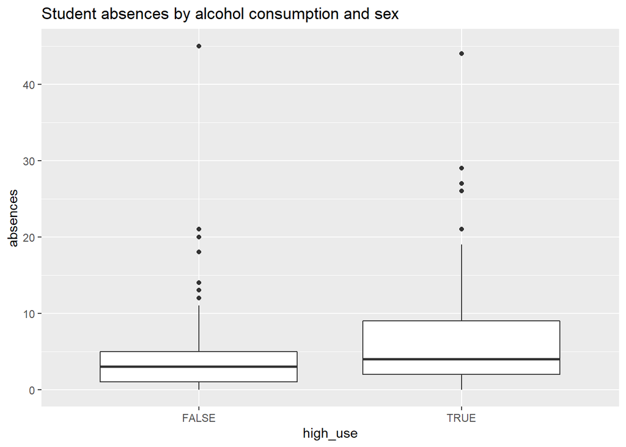

```r
library(dplyr); library(ggplot2)
#box plot
g1 <- ggplot(alc, aes(x = high_use, y = absences))
g1 + geom_boxplot() + ylab("absences") + ggtitle("Student absences by alcohol consumption and sex")
```

The first hypothesis seems to hold true, next weekly study time.

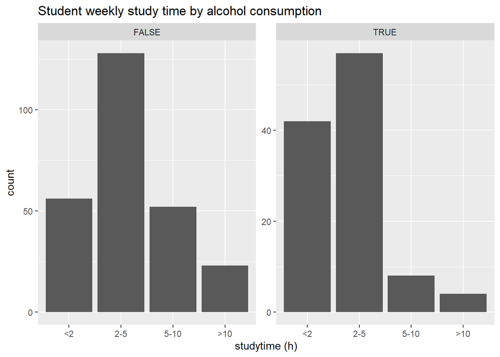

```r
#bar plot
g2 <- ggplot(data = alc,aes(x=factor(studytime)))
g2 + geom_bar() + facet_wrap("high_use", scales = "free_y")+ xlab("studytime (h)")+scale_x_discrete(labels=c("1" = "<2", "2" = "2-5","3" = "5-10","4" = ">10"))  + ggtitle("Student weekly study time by alcohol consumption")
```

Looking at the distribution, it is clear students with high alcohol use had less study time during the week as expected. Next, family relationship quality

```r
#cross tabulation
alc %>% group_by(high_use) %>% summarise(count = n(), mean_family_relationship_quality=mean(famrel))
```

```
## # A tibble: 2 × 3
##   high_use count mean_family_relationship_quality
##   <lgl>    <int>                            <dbl>
## 1 FALSE      259                             4.01
## 2 TRUE       111                             3.77
```

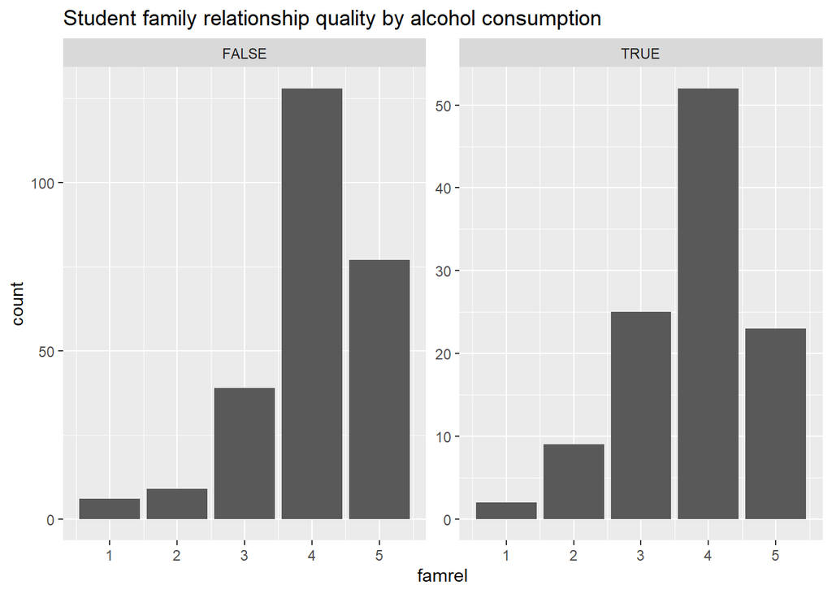

```r
#bar plot
g3 <- ggplot(data = alc,aes(x=famrel))
g3 + geom_bar() + facet_wrap("high_use",scales="free_y") + ggtitle("Student family relationship quality by alcohol consumption")
```

There is a small difference in the mean value as per the third hypothesis. Additionally, by looking at the distribution we can identify that for low alcohol use students the distribution is skewed to the left, whereas for high alcohol use students it is more normally distributed. Finally, health is looked at.

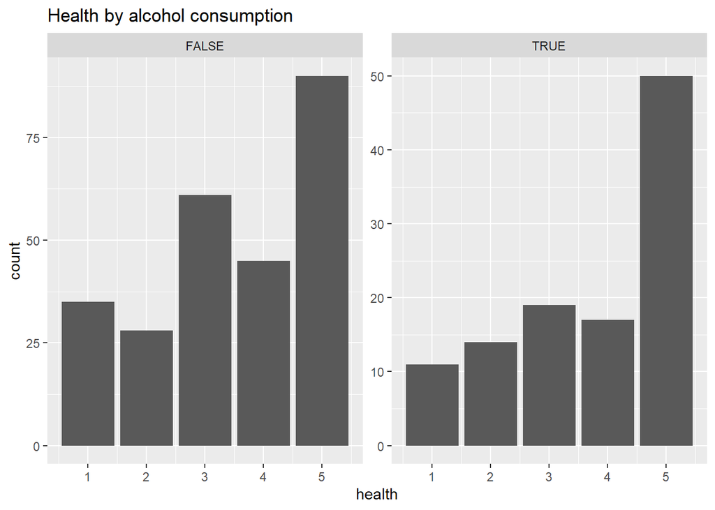

```r
#bar plot
g4 <- ggplot(data = alc,aes(x=health))
g4 + geom_bar() + facet_wrap("high_use",scales="free_y") + ggtitle("Health by alcohol consumption")
```

Interestingly, here the hypothesis was proven wrong. High alcohol use students reported their health to be in the best quality far more than low alcohol use students, who had a more variable distribution.  
Overall, 3/4 hypotheses proved correct. Why in this population the last hypothesis on alcohol consumption and health was incorrect could be due to higher outgoingness in the high use group, which would result in more physical activity. It could also be explained by self-report bias.

### 5. Logistic regression model

Using these variables, we will create a logistic regression model for alcohol consumption.

```r
m <- glm(high_use ~ absences + studytime + famrel + health, data = alc, family = "binomial")
#summary of the model
summary(m)
```

```
##
## Call:
## glm(formula = high_use ~ absences + studytime + famrel + health,
##     family = "binomial", data = alc)
##
## Deviance Residuals:
##     Min       1Q   Median       3Q      Max
## -2.2118  -0.8257  -0.6367   1.1877   2.1088
##
## Coefficients:
##             Estimate Std. Error z value Pr(>|z|)
## (Intercept)  0.46728    0.66691   0.701 0.483510
## absences     0.07667    0.02254   3.402 0.000670 ***
## studytime   -0.54552    0.15722  -3.470 0.000521 ***
## famrel      -0.27725    0.12933  -2.144 0.032045 *
## health       0.12762    0.08747   1.459 0.144565
## ---
## Signif. codes:  0 '***' 0.001 '**' 0.01 '*' 0.05 '.' 0.1 ' ' 1
##
## (Dispersion parameter for binomial family taken to be 1)
##
##     Null deviance: 452.04  on 369  degrees of freedom
## Residual deviance: 413.70  on 365  degrees of freedom
## AIC: 423.7
##
## Number of Fisher Scoring iterations: 4
```

```r
#get odds ratios
OR <- coef(m) %>% exp
#get confidence intervals
CI <- confint(m) %>% exp
#print both
cbind(OR, CI)
```

```
##                    OR     2.5 %    97.5 %
## (Intercept) 1.5956550 0.4296568 5.9289512
## absences    1.0796821 1.0351723 1.1312382
## studytime   0.5795420 0.4216137 0.7820553
## famrel      0.7578629 0.5871334 0.9765758
## health      1.1361197 0.9591423 1.3526070
```

### 6. Predictive power

We’ll only take the significant variables and see how this model performs.

```r
#make new model
new_m <- glm(high_use ~ absences + studytime + famrel, data = alc, family = "binomial")
#predict for each student whether they are high_use or not based on the variables
alc <- mutate(alc, probability = predict(new_m, type = "response"))
alc <- mutate(alc, prediction = probability > 0.5)

#cross tabulation
table(high_use = alc$high_use, prediction = alc$prediction) %>% prop.table()
```

```
##         prediction
## high_use      FALSE       TRUE
##    FALSE 0.65945946 0.04054054
##    TRUE  0.25405405 0.04594595
```

```r
#optionally calculate training error with loss function
loss_func <- function(class, prob) {
  n_wrong <- abs(class - prob) > 0.5
  mean(n_wrong)
}
loss_func(class = alc$high_use, prob = alc$probability)
```

```
## [1] 0.2945946
```

```r
#creating simple guessing strategy, randomly assign a number for each student within the range of student number
random_num <- sample(1:nrow(alc),nrow(alc))
alc <- mutate(alc, rand = random_num)
#count the number of high use students
num_high_use <- sum(alc$high_use)
#if the random index is below the number of high use students predict them as a high use student
alc <- mutate(alc, naive_prediction = rand < num_high_use)
#this results in random guessing, but at least the proportion of high use students should be similar
print("True number of high use students:")
```

```
## [1] "True number of high use students:"
```

```r
sum(alc$high_use)
```

```
## [1] 111
```

```r
print("Randomly assigned number of high use students:")
```

```
## [1] "Randomly assigned number of high use students:"
```

```r
sum(alc$naive_prediction)
```

```
## [1] 110
```

```r
#finally, test its function with cross tabulation
table(high_use = alc$high_use, prediction = alc$naive_prediction) %>% prop.table()
```

```
##         prediction
## high_use     FALSE      TRUE
##    FALSE 0.5054054 0.1945946
##    TRUE  0.1972973 0.1027027
```

### 7. 10-fold cross validation

Next, we will check its predictive power using a 10-fold cross-validation.

```r
library(boot)
cv10 <- cv.glm(data = alc, cost = loss_func, glmfit = new_m, K = 10)
cv10$delta[1]
```

```
## [1] 0.2918919
```

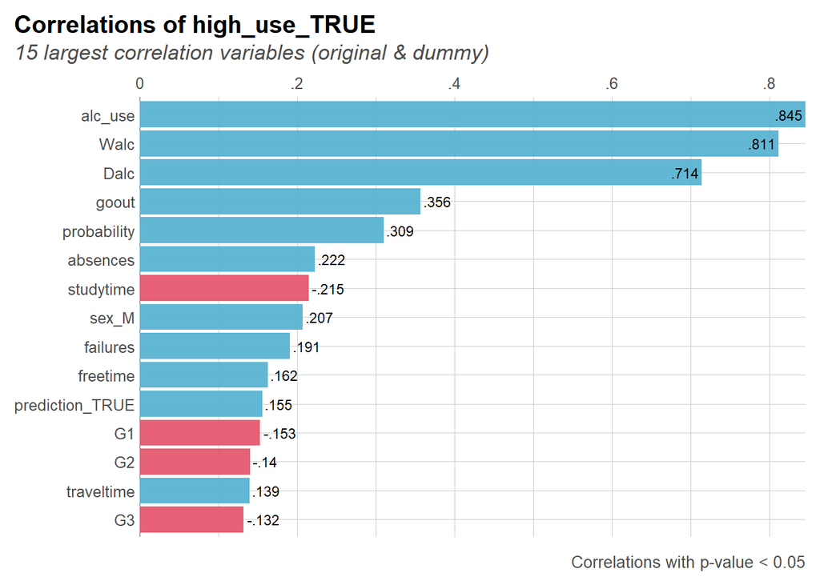

```r
library(lares)
#find highest correlations with a quick and dirty method found via google: https://statsandr.com/blog/correlogram-in-r-how-to-highlight-the-most-correlated-variables-in-a-dataset/
corr_var(alc,high_use,max_pvalue=0.05,top=15)
```

```r
better_m <- glm(high_use ~ goout + absences + studytime + sex, data = alc, family= "binomial")
#check significance, if variables not significant iterate ^
summary(better_m)
```

```
##
## Call:
## glm(formula = high_use ~ goout + absences + studytime + sex,
##     family = "binomial", data = alc)
##
## Deviance Residuals:
##     Min       1Q   Median       3Q      Max
## -1.9330  -0.7896  -0.4956   0.7414   2.6125
##
## Coefficients:
##             Estimate Std. Error z value Pr(>|z|)
## (Intercept) -3.19268    0.59956  -5.325 1.01e-07 ***
## goout        0.72483    0.12086   5.997 2.01e-09 ***
## absences     0.07853    0.02274   3.454 0.000553 ***
## studytime   -0.43466    0.17177  -2.530 0.011393 *
## sexM         0.83999    0.27053   3.105 0.001903 **
## ---
## Signif. codes:  0 '***' 0.001 '**' 0.01 '*' 0.05 '.' 0.1 ' ' 1
##
## (Dispersion parameter for binomial family taken to be 1)
##
##     Null deviance: 452.04  on 369  degrees of freedom
## Residual deviance: 367.31  on 365  degrees of freedom
## AIC: 377.31
##
## Number of Fisher Scoring iterations: 4
```

```r
better_cv10 <- cv.glm(data = alc, cost = loss_func, glmfit = better_m, K = 10)
better_cv10$delta[1]
```

```
## [1] 0.2054054
```

In the end, to keep all variables statistically significant, best ones noted were going out with friends, absences, study time and sex. This resulted in a model with an error of ~0.21.

### 8. Comparing different logistic models

Let’s start with 10 best predictors collected from previous graph and gradually lessen them.

```r
model_errors <- numeric(0)
model_errors[10] <-cv.glm(data = alc, cost = loss_func, glmfit = glm(high_use ~ goout + absences + studytime + sex + failures + freetime + G1 + G2 + traveltime + G3, data = alc, family= "binomial"), K = 10)$delta[1]
model_errors[9] <-cv.glm(data = alc, cost = loss_func, glmfit = glm(high_use ~ goout + absences + studytime + sex + failures + freetime + G1 + G2 + traveltime, data = alc, family= "binomial"), K = 10)$delta[1]
model_errors[8] <-cv.glm(data = alc, cost = loss_func, glmfit = glm(high_use ~ goout + absences + studytime + sex + failures + freetime + G1 + G2, data = alc, family= "binomial"), K = 10)$delta[1]
model_errors[7] <-cv.glm(data = alc, cost = loss_func, glmfit = glm(high_use ~ goout + absences + studytime + sex + failures + freetime + G1, data = alc, family= "binomial"), K = 10)$delta[1]
model_errors[6] <-cv.glm(data = alc, cost = loss_func, glmfit = glm(high_use ~ goout + absences + studytime + sex + failures + freetime, data = alc, family= "binomial"), K = 10)$delta[1]
model_errors[5] <-cv.glm(data = alc, cost = loss_func, glmfit = glm(high_use ~ goout + absences + studytime + sex + failures, data = alc, family= "binomial"), K = 10)$delta[1]
model_errors[4] <-cv.glm(data = alc, cost = loss_func, glmfit = glm(high_use ~ goout + absences + studytime + sex, data = alc, family= "binomial"), K = 10)$delta[1]
model_errors[3] <-cv.glm(data = alc, cost = loss_func, glmfit = glm(high_use ~ goout + absences + studytime, data = alc, family= "binomial"), K = 10)$delta[1]
model_errors[2] <-cv.glm(data = alc, cost = loss_func, glmfit = glm(high_use ~ goout + absences, data = alc, family= "binomial"), K = 10)$delta[1]
model_errors[1] <-cv.glm(data = alc, cost = loss_func, glmfit = glm(high_use ~ goout, data = alc, family= "binomial"), K = 10)$delta[1]

predictor_num <- c(1:10)
df <- data.frame(model_errors,predictor_num)
colnames(df)
```

```
## [1] "model_errors"  "predictor_num"
```

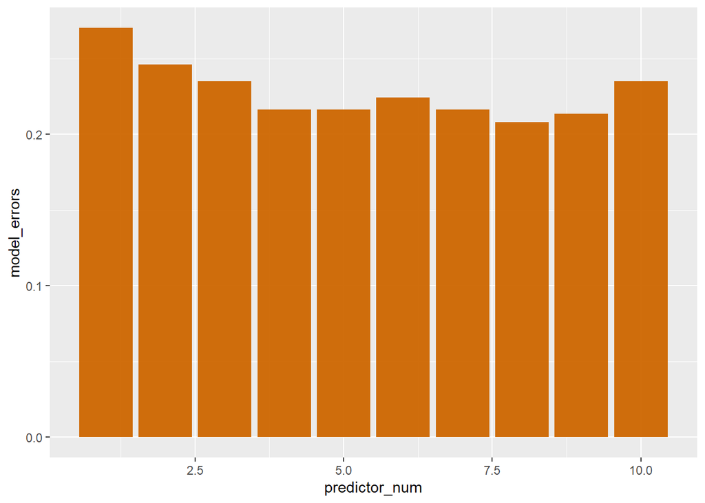

```r
g5 <- ggplot(data = df,aes(x=predictor_num,y=model_errors))
g5 + geom_bar(stat = "identity")
```

After the first 4 predictors the error doesn’t keep decreasing and instead flatlines, sometimes even increasing. This is probably a case of overfitting.